# BSL Angle Processing analysis

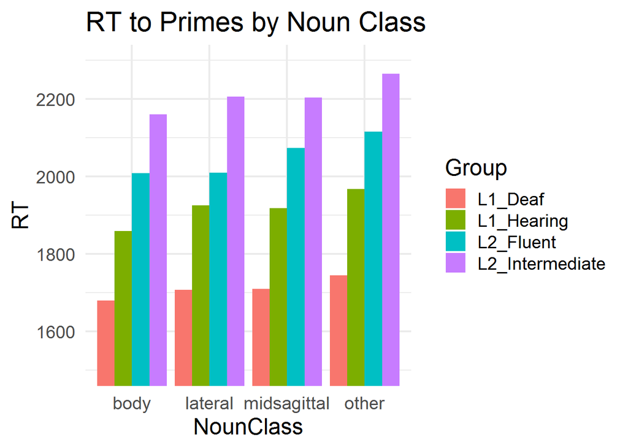

```r
vpRTPrimes %>% group_by(NounClass, Group) %>%
  summarize(RT = mean(RT)) %>%
  ggplot(aes(x = NounClass, y = RT, fill = Group)) +
  geom_bar(stat = 'identity', position = position_dodge()) +
  coord_cartesian(ylim = c(1500, 2300)) +
  theme_minimal(base_size = 18) +
  ggtitle('RT to Primes by Noun Class')
```

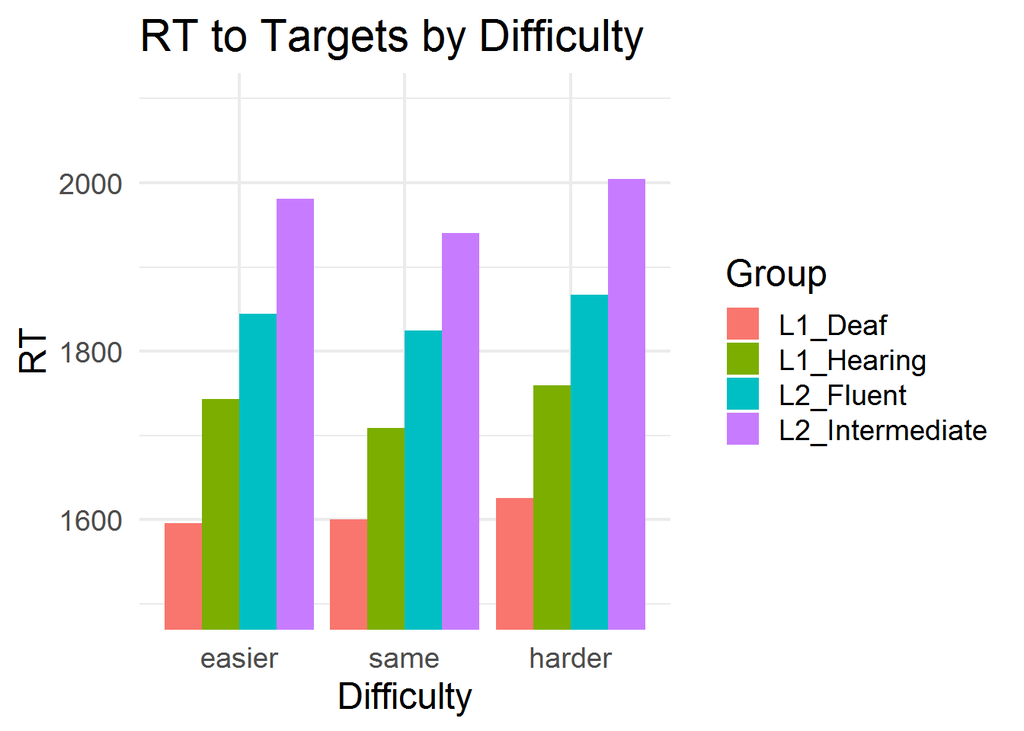

```r
vpRTTargets %>% filter(Difficulty != 'exclude',
              Difficulty != 'opposite') %>%
  group_by(Difficulty, Group) %>%
  summarize(RT = mean(RT)) %>%
    ggplot(aes(factor(Difficulty, level = c("easier", "same", "harder")),
               y = RT, fill = Group)) +
  geom_bar(stat = 'identity', position = position_dodge()) +
  coord_cartesian(ylim = c(1500, 2100)) +
  theme_minimal(base_size = 18) +
  ggtitle('RT to Targets by Difficulty') + xlab('Difficulty')
```

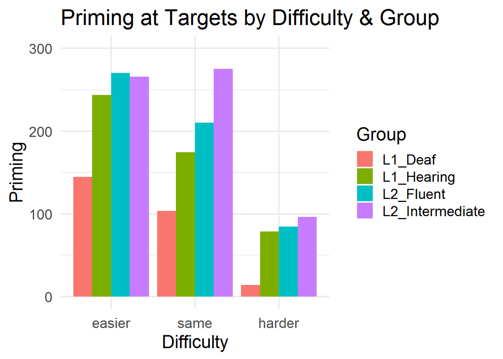

```r
vpRTTargets %>% filter(Difficulty != 'exclude',
              Difficulty != 'opposite') %>%
  group_by(Difficulty, Group) %>%
  summarize(Priming = mean(Priming)) %>%
    ggplot(aes(x = factor(Difficulty, level = c("easier", "same", "harder")),
               y = Priming, fill = Group)) +
  geom_bar(stat = 'identity', position = position_dodge()) +
  coord_cartesian(ylim = c(0, 300)) +
  theme_minimal(base_size = 18) +
  ggtitle('Priming at Targets by Difficulty & Group') + xlab('Difficulty')
```

# By-subject plots

Create by-subject plots:

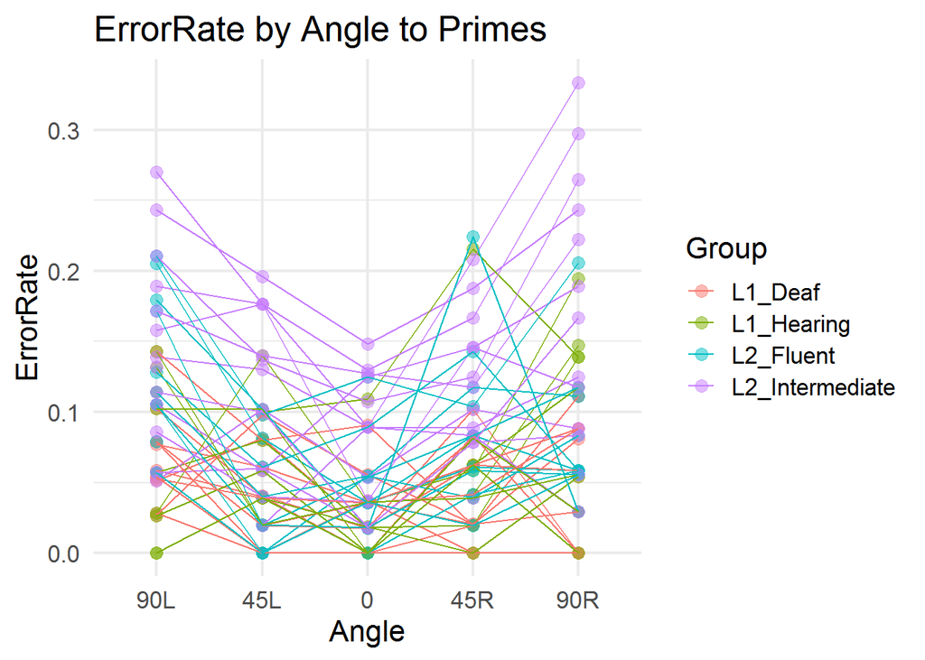

```r
vpAccPrimes %>% group_by(AngleLR, Group, Subject) %>%
  summarize(ErrorRate = mean(ErrorRate)) %>%
  ggplot(aes(x = factor(AngleLR, level = c("90L", "45L", "0", "45R", "90R")),
             y = ErrorRate, group=Subject, colour = Group)) +
  geom_point(size = 3, alpha = 0.5) +
  geom_line(aes(x = factor(AngleLR, level = c("90L", "45L", "0", "45R", "90R")),
                y = ErrorRate, group=Subject, colour = Group)) +
  theme_minimal(base_size = 16) +
  ggtitle('ErrorRate by Angle to Primes') + xlab('Angle')
```

[figure not shown]

```r
vpAccPrimes %>% group_by(Angle, Group, Subject) %>%
  summarize(ErrorRate = mean(ErrorRate)) %>%
  ggplot(aes(x = Angle, y = ErrorRate, group=Subject, colour = Group)) +
  geom_point(size = 3, alpha = 0.5) +
  geom_line(aes(x = Angle, y = ErrorRate, group=Subject, colour = Group)) + geom_dl(aes(x = Angle, y = ErrorRate, label = Subject),
          method = list(dl.combine("last.points"), cex = 0.8)) +
  coord_cartesian(xlim = c(0, 100)) +
  theme_minimal(base_size = 16) +
  ggtitle('ErrorRate by Angle to Primes') + xlab('Angle')
```

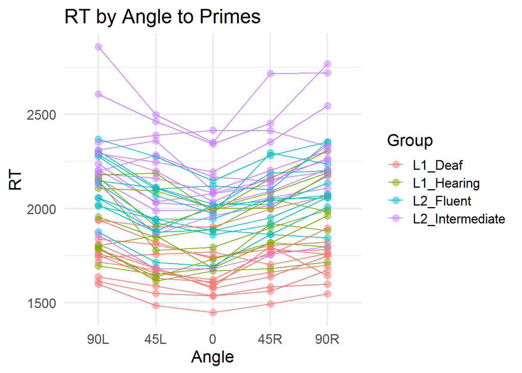

```r
vpRTPrimes %>% group_by(AngleLR, Group, Subject) %>%
  summarize(RT = mean(RT)) %>%
  ggplot(aes(x = factor(AngleLR, level = c("90L", "45L", "0", "45R", "90R")),
                        y = RT, group=Subject, colour = Group)) +
  geom_point(size = 3, alpha = 0.5) +
  geom_line(aes(x = factor(AngleLR, level = c("90L", "45L", "0", "45R", "90R")),
                y = RT, group=Subject, colour = Group)) +
  theme_minimal(base_size = 16) +
  ggtitle('RT by Angle to Primes') + xlab('Angle')
```

[figure not shown]

```r
vpRTPrimes %>% group_by(Angle, Group, Subject) %>%
  summarize(RT = mean(RT)) %>% ggplot(aes(x = Angle, y = RT, group=Subject, colour = Group)) + geom_point(size = 3, alpha = 0.5) +
  geom_line(aes(x = Angle, y = RT, group=Subject, colour = Group)) + geom_dl(aes(x = Angle, y = RT, label = Subject),
          method = list(dl.combine("last.points"), cex = 0.8)) +
  coord_cartesian(xlim = c(0, 100)) + theme_minimal(base_size = 16) + ggtitle('RT by Angle to Primes') + xlab('Angle')
```

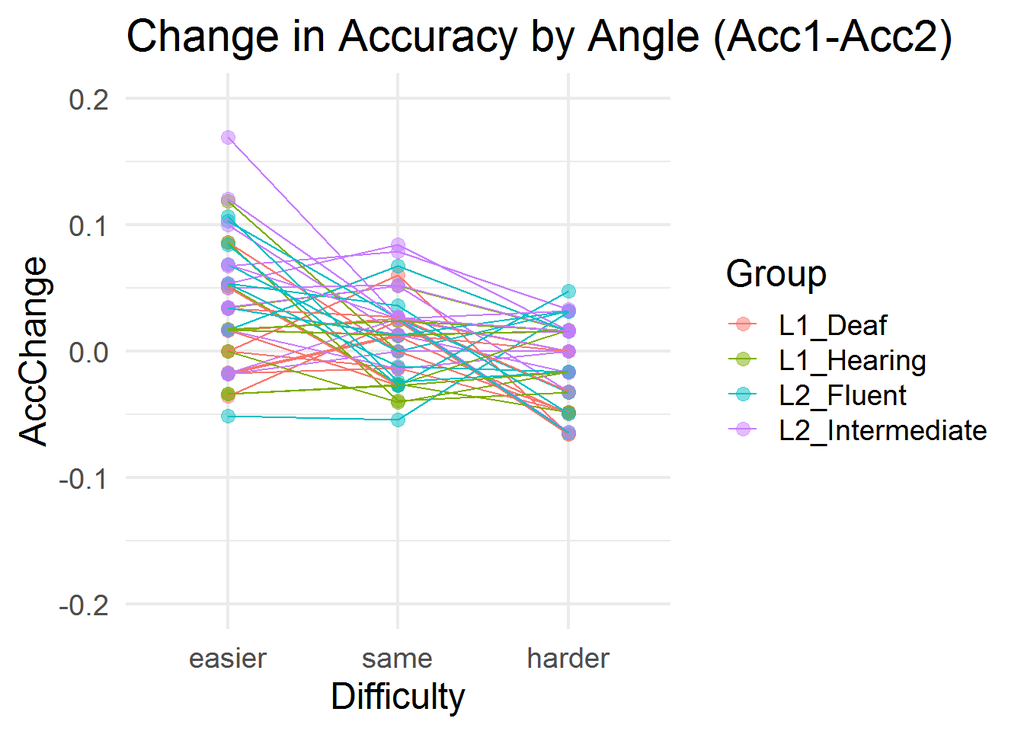

```r
vpAccTargets %>% group_by(Difficulty, Group, Subject) %>%
  summarize(AccChange = mean(AccChange)) %>%
  ggplot(aes(x = factor(Difficulty, level = c("easier", "same", "harder")),
             y = AccChange, group=Subject, colour = Group)) +
  coord_cartesian(ylim = c(-0.2, 0.2)) +
  geom_point(size = 3, alpha = 0.5) +
  geom_line(aes(x = factor(Difficulty, level = c("easier", "same", "harder")),
                y = AccChange, group=Subject, colour = Group)) +
  theme_minimal(base_size = 18) +
  ggtitle('Change in Accuracy by Angle (Acc1-Acc2)') + xlab('Difficulty')
```

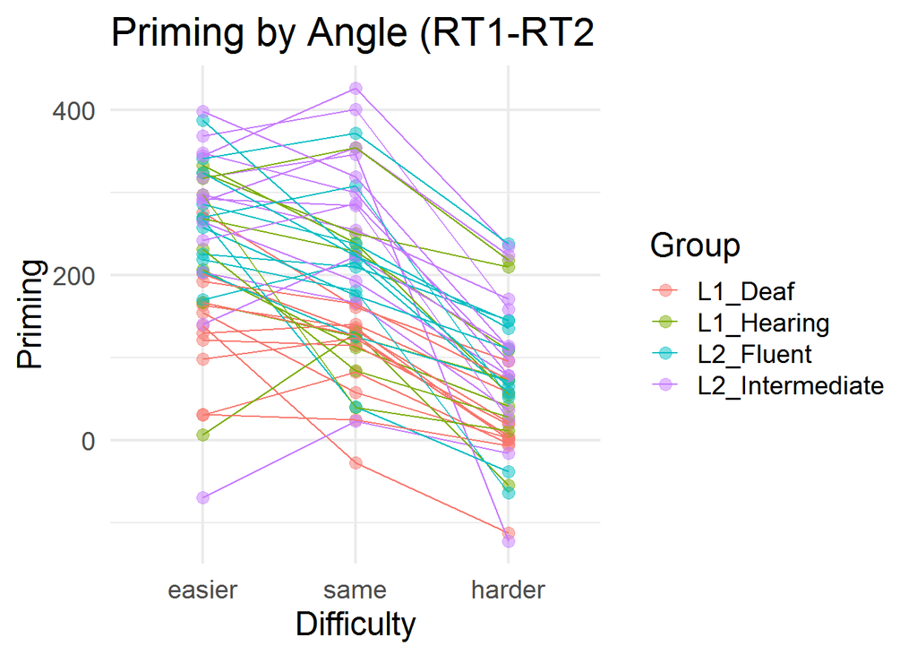

```r
vpRTTargets %>% group_by(Difficulty, Group, Subject) %>%
  summarize(Priming = mean(Priming)) %>%
  ggplot(aes(x = factor(Difficulty, level = c("easier", "same", "harder")),
             y = Priming, group=Subject, colour = Group)) +
  geom_point(size = 3, alpha = 0.5) +
  geom_line(aes(x = factor(Difficulty, level = c("easier", "same", "harder")),
                y = Priming, group=Subject, colour = Group)) +
  theme_minimal(base_size = 18) +
  ggtitle('Priming by Angle (RT1-RT2') + xlab('Difficulty')
```

These are maybe too busy to use, but could be worth producing these by-subject graphs side-by-side for each group.

Leaving out the item-level analysis code for now (which will be more relevant to the other paper) - let’s move on to the LMMs.

## Mixed Model Analysis, 1st half of experiment

First attempt at the mixed model for the Error analysis on Primes only (i.e. 1st half of the experiment)

```r
PrimeErrors <- mixed(ErrorRate ~ Angle*Group  + (1 + Angle|Subject) +
               (1 + Angle|Sign), vpAccPrimes, all_fit = TRUE, method = "LRT",
               control = lmerControl(optCtrl = list(maxfun = 1e6)))
```

```
## Contrasts set to contr.sum for the following variables: Angle, Group, Subject, Sign
```

```
## REML argument to lmer() set to FALSE for method = 'PB' or 'LRT'
```

```
## Fitting 4 (g)lmer() models:
## [
```

```
## singular fit
```

```
## singular fit
```

```
## singular fit
## singular fit
```

```
## .
```

```
## singular fit
```

```
## singular fit
## singular fit
## singular fit
```

```
## .
```

```
## singular fit
```

```
## singular fit
## singular fit
## singular fit
```

```
## .
```

```
## singular fit
```

```
## .]
```

```r
print(PrimeErrors)
```

```
## Mixed Model Anova Table (Type 3 tests, LRT-method)
##
## Model: ErrorRate ~ Angle * Group + (1 + Angle | Subject) + (1 + Angle |
## Model:     Sign)
## Data: vpAccPrimes
## Df full model: 25
##        Effect df     Chisq p.value
## 1       Angle  2 17.24 ***   .0002
## 2       Group  3 24.46 ***  <.0001
## 3 Angle:Group  6      6.80     .34
## ---
## Signif. codes:  0 '***' 0.001 '**' 0.01 '*' 0.05 '+' 0.1 ' ' 1
```

```r
summary(PrimeErrors)
```

```
## Linear mixed model fit by maximum likelihood . t-tests use
##   Satterthwaite's method [lmerModLmerTest]
## Formula: ErrorRate ~ Angle * Group + (1 + Angle | Subject) + (1 + Angle |
##     Sign)
##    Data: dots$data
## Control: ctrl
##
##      AIC      BIC   logLik deviance df.resid
##   1371.2   1551.9   -660.6   1321.2    10175
##
## Scaled residuals:
##     Min      1Q  Median      3Q     Max
## -1.7829 -0.4058 -0.1752 -0.0303  4.1005
##
## Random effects:
##  Groups   Name        Variance  Std.Dev.  Corr
##  Sign     (Intercept) 4.865e-03 0.0697462
##           Angle1      5.105e-04 0.0225951 -0.85
##           Angle2      7.489e-05 0.0086537 -1.00  0.84
##  Subject  (Intercept) 9.408e-04 0.0306722
##           Angle1      9.696e-05 0.0098469 -1.00
##           Angle2      4.749e-07 0.0006891 -1.00  1.00
##  Residual             6.397e-02 0.2529316
## Number of obs: 10200, groups:  Sign, 227; Subject, 45
##
## Fixed effects:
##                 Estimate Std. Error         df t value Pr(>|t|)
## (Intercept)    7.419e-02  7.078e-03  1.157e+02  10.481  < 2e-16 ***
## Angle1        -1.709e-02  5.241e-03  1.298e+02  -3.261  0.00142 **
## Angle2        -6.655e-03  4.252e-03  1.416e+03  -1.565  0.11783
## Group1        -2.930e-02  8.928e-03  4.508e+01  -3.282  0.00200 **
## Group2        -1.545e-02  9.845e-03  4.509e+01  -1.569  0.12362
## Group3        -1.652e-03  9.187e-03  4.507e+01  -0.180  0.85807
## Angle1:Group1  1.155e-02  7.094e-03  1.650e+02   1.628  0.10546
## Angle2:Group1 -2.522e-03  5.757e-03  6.517e+03  -0.438  0.66134
## Angle1:Group2 -3.235e-03  7.825e-03  1.652e+02  -0.413  0.67987
## Angle2:Group2  9.217e-03  6.345e-03  6.516e+03   1.453  0.14636
## Angle1:Group3  2.099e-03  7.295e-03  1.646e+02   0.288  0.77392
## Angle2:Group3 -5.886e-03  5.924e-03  6.537e+03  -0.994  0.32045
## ---
```

[output cut: 14 more lines]

```
## Angle2:Grp3 -0.001  0.001  0.007  0.041  0.051 -0.132  0.146 -0.315  0.176
##             An2:G2 An1:G3
## Angle1
## Angle2
## Group1
## Group2
## Group3
## Angle1:Grp1
## Angle2:Grp1
## Angle1:Grp2
## Angle2:Grp2
## Angle1:Grp3  0.177
## Angle2:Grp3 -0.380 -0.463
## convergence code: 0
## singular fit
```

Seems to converge… However I’m not sure if the random slope syntax is right (or for the following models). All participants see every sign once, but signs allowed to vary by angle (Angle). So diff ppts will see see same sign from diff angle. However, not all signs appear from every angle as items imbalanced. Correlation of random effects probably too strong to be reliable - suggests something wrong with model? But if true, participants who have higher intercepts have steeper angle slopes. Makes sense that only the participants who found the task difficult at 0deg show a stronger interference effect of angle. (see Fig 81, p.271)

Multiple comparisons for the PrimeErrors model:

```r
PrimeAccPairwise = emmeans(PrimeErrors, specs = trt.vs.ctrl ~ Angle:Group, data = vpAccPrimes)
```

```
## Note: D.f. calculations have been disabled because the number of observations exceeds 3000.
## To enable adjustments, set emm_options(pbkrtest.limit = 10200) or larger,
## but be warned that this may result in large computation time and memory use.
```

```
## Note: D.f. calculations have been disabled because the number of observations exceeds 3000.
## To enable adjustments, set emm_options(lmerTest.limit = 10200) or larger,
## but be warned that this may result in large computation time and memory use.
```

```r
PrimeAccPairwise
```

```
## $emmeans
##  Angle Group           emmean     SE  df asymp.LCL asymp.UCL
##  0     L1_Deaf         0.0393 0.0123 Inf    0.0152    0.0635
##  45    L1_Deaf         0.0357 0.0122 Inf    0.0118    0.0596
##  90    L1_Deaf         0.0596 0.0165 Inf    0.0273    0.0920
##  0     L1_Hearing      0.0384 0.0140 Inf    0.0109    0.0659
##  45    L1_Hearing      0.0613 0.0138 Inf    0.0342    0.0884
##  90    L1_Hearing      0.0765 0.0186 Inf    0.0400    0.1130
##  0     L2_Fluent       0.0575 0.0128 Inf    0.0325    0.0826
##  45    L2_Fluent       0.0600 0.0127 Inf    0.0352    0.0848
##  90    L2_Fluent       0.1001 0.0171 Inf    0.0665    0.1337
##  0     L2_Intermediate 0.0931 0.0119 Inf    0.0697    0.1164
##  45    L2_Intermediate 0.1131 0.0118 Inf    0.0900    0.1362
##  90    L2_Intermediate 0.1556 0.0160 Inf    0.1242    0.1869
##
## Degrees-of-freedom method: asymptotic
## Confidence level used: 0.95
##
## $contrasts
##  contrast                        estimate     SE  df z.ratio p.value
##  45,L1_Deaf - 0,L1_Deaf         -0.003632 0.0132 Inf -0.275  0.9992
##  90,L1_Deaf - 0,L1_Deaf          0.020267 0.0157 Inf  1.291  0.7371
##  0,L1_Hearing - 0,L1_Deaf       -0.000929 0.0176 Inf -0.053  1.0000
##  45,L1_Hearing - 0,L1_Deaf       0.021960 0.0179 Inf  1.225  0.7747
##  90,L1_Hearing - 0,L1_Deaf       0.037162 0.0215 Inf  1.726  0.4564
##  0,L2_Fluent - 0,L1_Deaf         0.018200 0.0166 Inf  1.094  0.8417
##  45,L2_Fluent - 0,L1_Deaf        0.020653 0.0170 Inf  1.212  0.7819
##  90,L2_Fluent - 0,L1_Deaf        0.060727 0.0203 Inf  2.993  0.0256
##  0,L2_Intermediate - 0,L1_Deaf   0.053744 0.0160 Inf  3.365  0.0076
##  45,L2_Intermediate - 0,L1_Deaf  0.073784 0.0164 Inf  4.501  0.0001
##  90,L2_Intermediate - 0,L1_Deaf  0.116216 0.0193 Inf  6.015  <.0001
##
## P value adjustment: dunnettx method for 11 tests
```

Had to recode Angle as a factor in order to get it to work for multiple comparisons in emmeans I specified ‘0,L1_Deaf’ as the control (not sure if this is a good way to do it)